# PA1_template.Rmd

## 2. What is the average daily activity pattern?

#### Rcode, Output, and Visualization

```r
# 5 Minutes Interval
# Creating Dataframe
dat2 <- dat %>% mutate(Date = as.Date(date)) %>%
  select(-date) %>% group_by(interval)%>% summarize(Average_Steps = mean(steps, na.rm = TRUE))
head(dat2, 5)
```

```
Source: local data frame [5 x 2]

  interval Average_Steps
     (int)         (dbl)
1        0     1.7169811
2        5     0.3396226
3       10     0.1320755
4       15     0.1509434
5       20     0.0754717
```

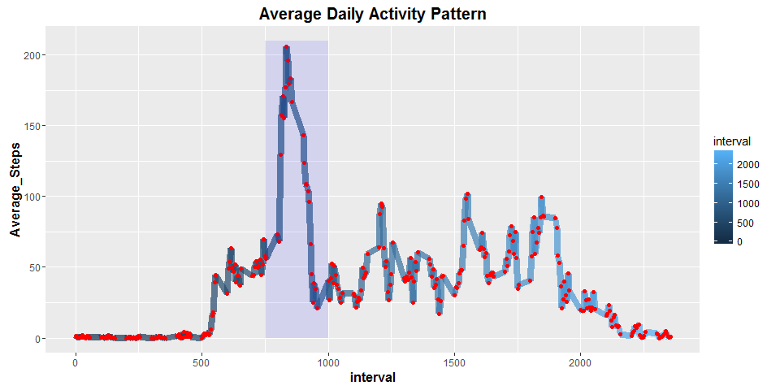

```r
plot_dat2 <- ggplot(dat2, aes(interval, Average_Steps, color = interval))+
  geom_line( size = 3, alpha = 0.7) +
  geom_point(colour = "red")+
  ggtitle("Average Daily Activity Pattern")+
  theme(plot.title = element_text(size = 15, face = "bold"),
        axis.title = element_text(size = 12, face = "bold"))+
  annotate("rect", xmin = 750, xmax = 1000, ymin = 0, ymax = 210, alpha = 0.1, fill ="blue")

  plot_dat2
```

### 2.1 Which 5-minute interval, on average, contains the maximum number of steps?

```r
max <- dat2[which.max(dat2$Average_Steps), ]
max #835      206.1698
```

```
Source: local data frame [1 x 2]

  interval Average_Steps
     (int)         (dbl)
1      835      206.1698
```

## 3. Imputing missing values

#### Rcode, Output, and Visualization

```r
#Missing Data
sum(!complete.cases(dat))
```

```
[1] 2304
```

```r
dat_miss <- dat %>% select(-date) %>% group_by(interval) %>% is.na %>% melt()
head(dat_miss)
```

```
  Var1  Var2 value
1    1 steps  TRUE
2    2 steps  TRUE
3    3 steps  TRUE
4    4 steps  TRUE
5    5 steps  TRUE
6    6 steps  TRUE
```

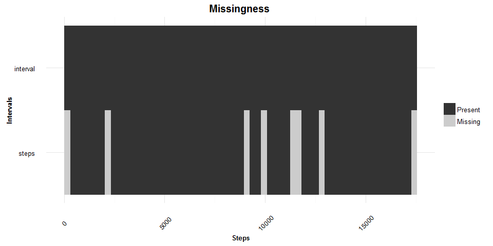

```r
p_dat_miss<- ggplot(dat_miss, aes(Var1, Var2)) +
  geom_raster(aes(fill = value)) +
  scale_fill_grey(name = "",
                  labels = c("Present","Missing"))+
  theme_minimal() +
  theme(axis.text.x = element_text(angle=45, vjust=0.5)) +
  labs(x = "Steps",
       y = "Intervals")+
  ggtitle("Missingness ") +
  theme(plot.title = element_text(size = 15, face = "bold"),
        axis.title = element_text(size = 10, face = "bold"))
p_dat_miss
```

### 3.1 Strategy for filling in all of the missing values in the dataset

#### Rcode, Output, and Visualization

```r
# Filling NAs
dat_fill <- dat %>% group_by(date) %>% summarize(Total_per_Day = sum(steps)) %>%
  mutate(New_Total_per_Day = zoo::na.fill(Total_per_Day, total_mean), Date = as.Date(date))%>%
  select(-date,-Total_per_Day)
head(dat_fill,5)
```

```
Source: local data frame [5 x 2]

  New_Total_per_Day       Date
              (dbl)     (date)
1          10766.19 2012-10-01
2            126.00 2012-10-02
3          11352.00 2012-10-03
4          12116.00 2012-10-04
5          13294.00 2012-10-05
```

```r
sum(!complete.cases(dat_fill)) # check if successfully filled
```

```
[1] 0
```

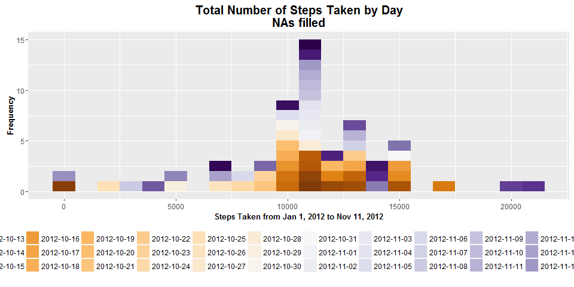

```r
## Plotting
## Creating palette
colourCount1 <- length(unique(dat1$Date))
getPalette1 <- colorRampPalette(brewer.pal(11, "PuOr"))


p_dat_fill <- ggplot(dat_fill, aes(New_Total_per_Day, fill= as.factor(Date)))+
  geom_histogram(binwidth = 1000)+
  ggtitle("Total Number of Steps Taken by Day\nNAs filled") +
  xlab("Steps Taken from Jan 1, 2012 to Nov 11, 2012") +
  ylab("Frequency")+
  scale_fill_manual(values = getPalette1(colourCount1))+
  theme(legend.position = "bottom", plot.title = element_text(size = 15,
                                                              face = "bold"),
        axis.title = element_text(size = 10, face = "bold"))+
  guides(fill=guide_legend(nrow=3),guide_legend(title=NULL))

p_dat_fill
```

### 3.2 Histogram of the total number of steps taken each day

#### Rcode, Output, and Visualization

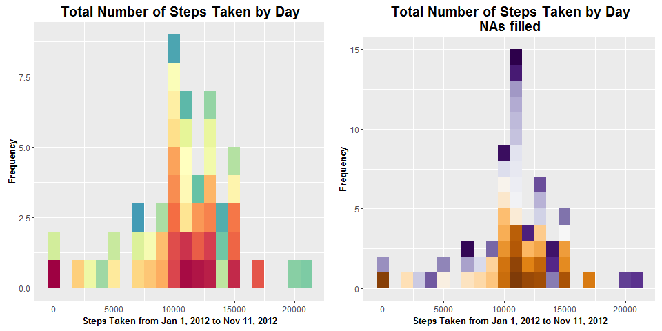

```r
# Aggregate histogram

p_dat1C <- ggplot(dat1, aes(Total_per_Day, fill= as.factor(Date)))+
  geom_histogram(binwidth = 1000)+
  ggtitle("Total Number of Steps Taken by Day") +
  xlab("Steps Taken from Jan 1, 2012 to Nov 11, 2012") +
  ylab("Frequency")+
  scale_fill_manual(values = getPalette(colourCount))+
  theme(legend.position = "bottom", plot.title = element_text(size = 15,
                                                              face = "bold"),
        axis.title = element_text(size = 10, face = "bold"))+
  guides(fill = FALSE)

p_dat_fillC <- ggplot(dat_fill, aes(New_Total_per_Day, fill= as.factor(Date)))+
  geom_histogram(binwidth = 1000)+
  ggtitle("Total Number of Steps Taken by Day\nNAs filled") +
  xlab("Steps Taken from Jan 1, 2012 to Nov 11, 2012") +
  ylab("Frequency")+
  scale_fill_manual(values = getPalette1(colourCount1))+
  theme(legend.position = "bottom", plot.title = element_text(size = 15,
                                                              face = "bold"),
        axis.title = element_text(size = 10, face = "bold"))+
  guides(fill = FALSE)

grid.arrange(p_dat1C, p_dat_fillC, ncol=2)
```

Since the total mean previously obtained has been used to replace the missing values, it does not come as a surprise that the two distributions, not being exactly equal, resemble each other.

### 3.3 Calculate and report the mean and median total number of steps taken per day

#### Rcode, Output, and Visualization

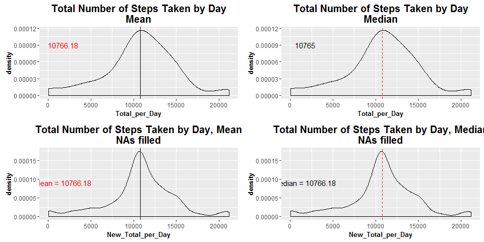

```r
#Mean and Median
Total_meanF <- mean(dat_fill$New_Total_per_Day)
total_medianF <- median(dat_fill$New_Total_per_Day)

mean_plotF <- ggplot(dat_fill, aes(New_Total_per_Day)) +
  geom_density()+
  geom_vline(aes(xintercept= Total_meanF)) +
  ggtitle("Total Number of Steps Taken by Day, Mean\nNAs filled") +
  theme(plot.title = element_text(size = 15, face = "bold"),
        axis.title = element_text(size = 10, face = "bold"))+
  annotate("text", x = 1750, y = 0.00009, label= "Mean = 10766.18", color = "red")+
  guides(fill = FALSE)

median_plotF <- ggplot(dat_fill, aes(New_Total_per_Day)) +
  geom_density()+
  geom_vline(aes(xintercept= total_medianF), linetype = "dashed", color = "red") +
  ggtitle("Total Number of Steps Taken by Day, Median\nNAs filled") +
  theme(plot.title = element_text(size = 15, face = "bold"),
        axis.title = element_text(size = 10, face = "bold"))+
  annotate("text", x=1750, y = 0.00009, label = "Median = 10766.18")+
  guides(fill = FALSE)

grid.arrange(mean_plot, median_plot, mean_plotF, median_plotF, ncol = 2)
```

No major differences as displayed by the comparative enclosed figure given the filling strategy already discussed. The median reports a slightly change.

## 4. Are there differences in activity patterns between weekdays and weekends?

#### Rcode, Output, and Visualization

```r
#Creating Weekdays
## Intervalsummarize(Average_Steps = mean(steps, na.rm = TRUE))
mean_steps <- mean(dat$steps, na.rm = TRUE)

dat2_WD <- dat %>% mutate(new_steps = zoo::na.fill(steps,mean_steps),
                          Date = as.Date(date), Days_of_the_Week = weekdays(Date)) %>%
  select(-date, -steps) %>% group_by(Days_of_the_Week, interval) %>%
  summarize(Total_Steps_per_Day = sum(new_steps))

dat2_WD1 <- dat2_WD %>% mutate(weektype = factor(Days_of_the_Week %in% c("Monday", "Tuesday", "Wednesday","Thursday", "Friday"),  levels = c("TRUE", "FALSE"),
                                        labels=c("WEEKDAY","WEEKEND")))
head(dat2_WD1) # check
```

```
Source: local data frame [6 x 4]
Groups: Days_of_the_Week [1]

  Days_of_the_Week interval Total_Steps_per_Day weektype
             (chr)    (int)               (dbl)   (fctr)
1           Friday        0             74.7652  WEEKDAY
2           Friday        5             74.7652  WEEKDAY
3           Friday       10             74.7652  WEEKDAY
4           Friday       15             74.7652  WEEKDAY
5           Friday       20             74.7652  WEEKDAY
6           Friday       25             74.7652  WEEKDAY
```

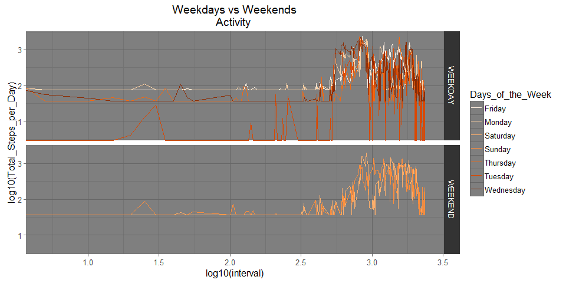

```r
p_dat2_WD1 <- ggplot(dat2_WD1, aes(log10(interval), log10(Total_Steps_per_Day), fill = weektype,
                                   color = Days_of_the_Week)) +
  geom_line(stat = "identity")+
  scale_colour_brewer(palette = "Oranges")+
  ggtitle("Weekdays vs Weekends\nActivity ") +
  theme(plot.title = element_text(size = 15, face = "bold"),
        axis.title = element_text(size = 10, face = "bold"))+
  theme_dark()+
  facet_grid(weektype~.)

p_dat2_WD1
```